# Amir Babar

##### e-mail | [LinkedIn](https://www.linkedin.com/in/amir-babar/)

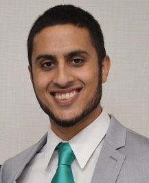

Hello! I’m Amir. Currently I am studying business analytics at the University of Cincinnati. Initially I came to Cincinnati in 2012 with the goal of becoming a physician scientist. Along the way I heard the call of analytics and data science, which led me to the College of Business. I am planning on graduating at the end of this year and hope to find a position after where I can apply and further develop my analytic skills.

### Academic Background

**University of Cincinnati, Carl H. Lindner College of Business**, Cincinnati, Ohio  
*Master of Science*, Business Analytics (Expected December 2018)

**University of Cincinnati, College of Medicine**, Cincinnati, Ohio  
*Master of Science*, Molecular Genetics, Biochemistry & Microbiology (April 2018)  
*Medical Student* (August 2012 – June 2014)

- Completed first half of medical school curriculum and passed USMLE Step 1 Examination

**Case Western Reserve University**, Cleveland, Ohio (May 2011)  
*Bachelor of Arts*, Chemistry, *Cum Laude* GPA: 3.6

### Experience with R

The majority of my exposure to R has come from previous business analytics courses in the past year. During that time I devoted a significant amount of time beyond the course requirements looking into how to make my code more reproducable and easier to understand when reading later on. I always seek to have files that can be run by anybody with only one click. My current goal is to write cleaner and more efficient code, and to write functions more often to streamline work when possible.